# Warming Climate and Colorado Snowpack

Andrew Wolfe

7/17/2018

The following article is a synopsis of my senior project. All of my code can be found on [**Github**](https://github.com/Roctober92/senior_project_scripts), and the *most in-depth analysis* can be found [here](https://byuidatascience.github.io/WolfeA_SeniorProject/). **Everything is formatted best for desktop screens**.

I’ve always been fascinated by the climate. Growing up in a town nestled up against the Front Range of the Rocky Mountains outside of Denver, I saw a little bit of everything. There are definitely four distinct seasons, but they don’t always happen when they are supposed to. And being so close to the mountains, the topic of discussion was always “When is the snow going to disappear so that we can go backpacking? Is there enough snow for all of the ski lifts to open? Will there be any wildfires?”

These type of frequently asked questions have always aroused my curiosity: can I answer these questions, but through data? Is there data available to be able to get my answers?

In recent years, there has arisen another climate question that has peaked the interest of not only climate lovers, but the general populous. The topic of **global warming** has become such a buzz word, that many question if it has any validity at all, due to it’s scientific approach becoming mixed up in political stances. However, a **warming climate**, even if it’s not directly caused by humans (taking the buzz out of the situation), has been observed, at least over the sample size which is the last 130 years, where we have been able to measure and record temperature consistently.

When empathizing the Denver channel 2 meteorologist, Matt Makens, about what kind of study Colorado Climate lovers really want to see get done, he suggested I analyze how **warming climate affects snow pack at different elevations**. Now why would this be important? Knowing how snow pack is affected at different elevations helps us plan how it affects different ski-towns, water run-off schedules, local ecology, and micro-climates .When he suggested this, I was ecstatic: it would be the opportunity to simultaneously answer my own personal questions while at the same time use data science for something impactful. So I decided to study just that.

With the suggestion of Mr. Makens, I decided to find data through a query tool provided by the *National Resources Conservation Service*, or [NRCS](https://www.nrcs.usda.gov). It provided me with 114 different [*SNOTEL*](https://en.wikipedia.org/wiki/SNOTEL) stations located in different [parts of Colorado](https://byuidatascience.github.io/WolfeA_SeniorProject/station_map.html), where I could find data for at least some stations dating back to 1978. The data was aggregated and can be measured in different time amounts: hourly, daily, semi-monthly, monthly, and yearly. But because of large data size for 40 years of data returned by NRCS, I decided to use *semi-monthly* observations: which means that every temperature was the *15 day average*, and that snow pack was measured every 15 days. This returned **75,480** rows.

I obtained metadata for each SNOTEL station through the *snotelr* package in R. The following is a snapshot of the data at this point.

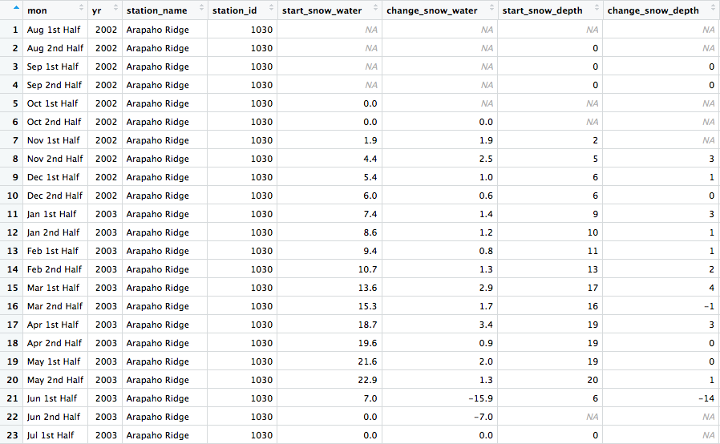

You can see already that I needed to format the date, and eventually work to either cut out or replace the *missing values* indicated by *NA*.

True to the adage, throughout the entirety of the analytical process, I can honestly say I used 90% of my time either formatting or imputing (re-estimating through statistical processes) data. The entirety of that process is explained [in my website](https://byuidatascience.github.io/WolfeA_SeniorProject/). But for this article, I’ll just briefly summarize the main tasks and problems.

Temperature Imputing

About 10,000 rows of the temperature data was either intuitively wrong (5000 degree observations), or missing. Here were some of the problems:

- Some stations reported 32 for both 15-day daily high and low
- Missing values in high, low, or both
- About the top and bottom 1% of data seemed even too extreme to be real

The following shows the shape of the data per month, and which observations I picked to be outliers.

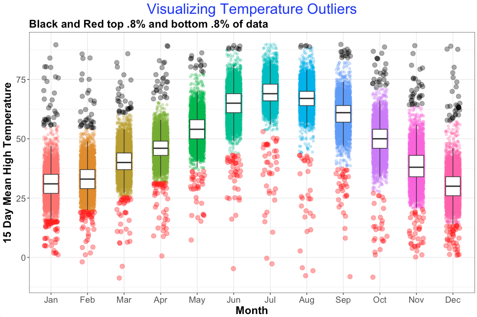

Now picking where to draw the line between the observations I assumed were good, and outliers, was arbitrary on my part. However, I figured even if a few rows of data that I labeled as *impossible* were the actual temperatues, that when I do the imputing, they shouldn’t be re-estimated too far away. After all, I only chose about the outside 2% of the data to impute.

At first I decided to impute the temperature through [**KNN Regression in Python**](https://roctober92.github.io/portfolio/topics/ml/knn.html), but that would only make predictions based off of combinations of month and elevations. Now that would make 936 different combinations, which is a pretty high numbers of different prediction combinations. But what this method does not account for is yearly and regional variation.

Therefore, J.Hathaway (my advisor) and I decided to go another route, where for every bad value, we’d find stations within 90 miles and 1000 ft. elevation of the same date, and make a list of them and their recordings. Then, we’d take the temperature average from all of them to be our imputed temperature (a custom KNN). If the criteria didn’t return anything, then instead of the same date, we found like stations of the same month. The method was validated [here](https://byuidatascience.github.io/WolfeA_SeniorProject/temp_validation.html), where it shows that most temperature predictions were within 5 degrees or less.

The following is the *good data* overlayed with the *imputed data*.

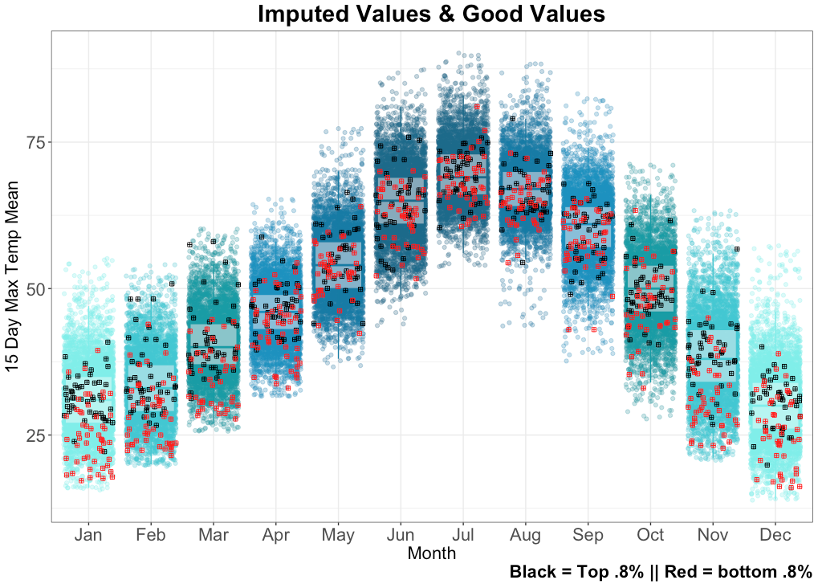

Snow Depth Imputing

After imputing the temperature, analysis of the **snow depth** measurements also showed some trouble. Mainly, from 1978-1996, there was no ability to measure snow pack at SNOTEL sites. Only beginning in 2003 were more than half able to. This meant that if I wanted to answer my question, I would answer it using data from 2003-2018, or I would **back-estimate** those values. I chose to **back-estimate**.

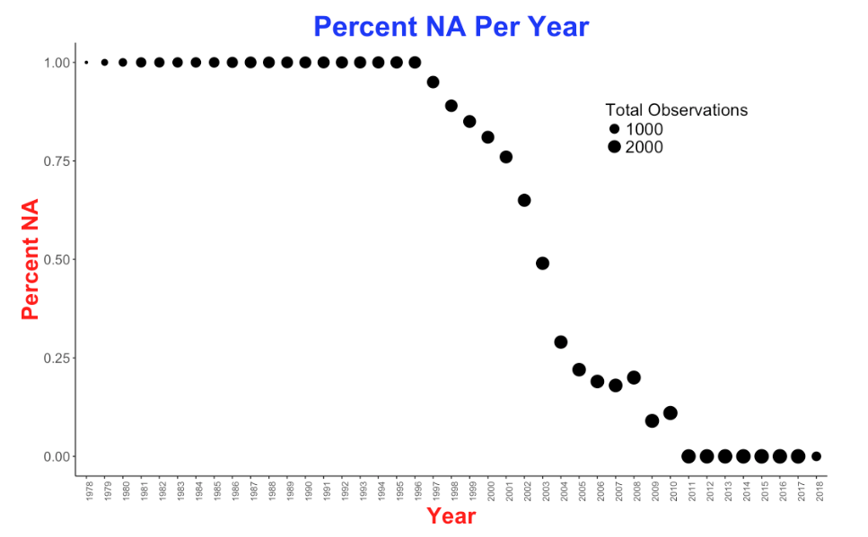

I was able to **impute backwards** because of one thing: each site measured the **snow water equivalent**, or **SWE**, even back to 1978. The **SWE** simply tells us how much liquid precipitation is in the snow pack. We can estimate **snow depth** using the **SWE** because they have a linear relationship.

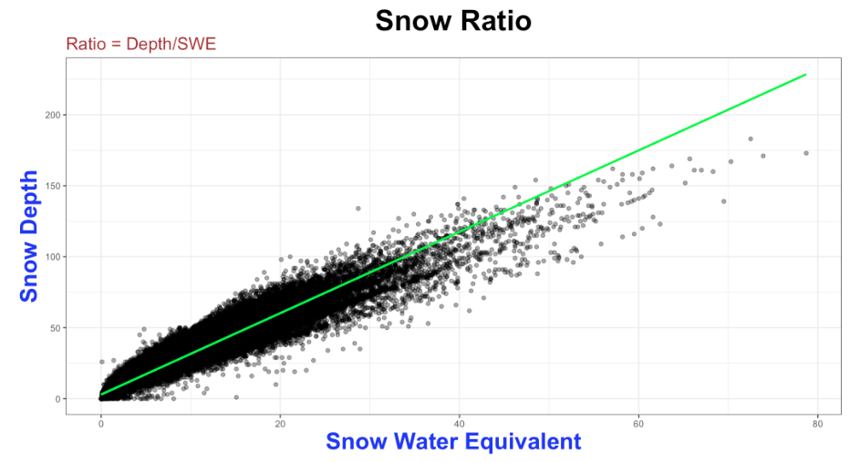

This relationship is called the **snow ratio**, or the linear coefficient between the two. The **snow ratio** [differs](https://byuidatascience.github.io/WolfeA_SeniorProject/snow_ratios.html) depending on temperature and time of year. Therefore, I decided to impute backwards using **multiple regression**, where each regression line represented a **snow ratio** of each month interracted with the **SWE**, with the **average temperature** *(high+low/2)* as an added term.

The following shows the multiple regression before any [transformation](https://byuidatascience.github.io/WolfeA_SeniorProject/find_regression.html). Note the **black dots**, which were snow depths that I concluded were also impossble, given the **SWE**, and were subsetted to be imputed.

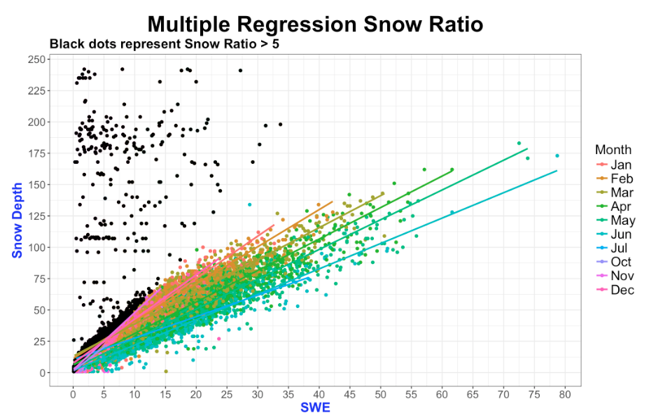

Validation of this model showed a .94 correlation, and was consistent for both training and test data.

After [imputing](https://byuidatascience.github.io/WolfeA_SeniorProject/apply_regression.html), the snow depths seemed to be about what intuition would tell us about Colorado snow pack: varied, and spring-heavy.

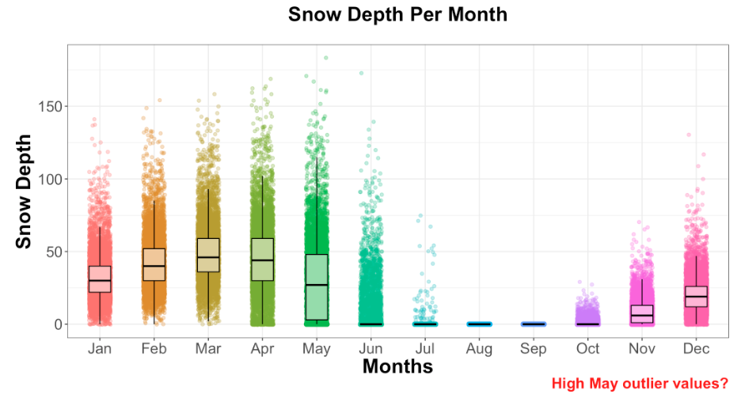

Warming Climate and Snow Depth

After hours of data wrangling and statistical processes, with limited time I finally got to take a look at my original focus: **warming climate affect snowpack at different elevations**.

First of all: is there a **warming climate** in the first place? Data shows that yes, especially in daily low temperatures. I submitted the following graphic to the **National Oceanic and Atmospheric Administration**, or *NOAA* asking if it could be correct, and they verified saying that it was.

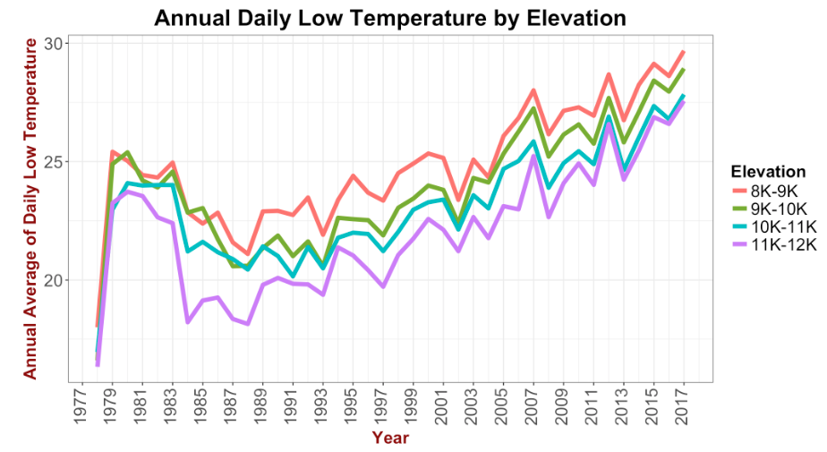

The warming trend over the last 30 years shows that it isn’t getting as cold at night anymore, which would intuitely tell us that snow pack would decrease faster.

How would this affect the [**snow season length yearly**](https://byuidatascience.github.io/WolfeA_SeniorProject/season_length.html), or **how many days there is snow on the ground**? This question is important because snow on the ground lowers daily temperature, and increases relative humidity, among other affects.

According to the graphic, an increase in temperature doesn’t seem to affect the snow pack at different elevations too much, but what it does show is how **snow season** varies among different elevations.

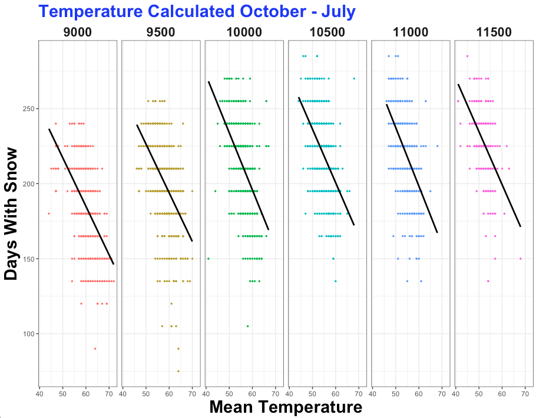

**Snow season** also decreases *(with a slight correlation)* with temperature, and a little more strongly over time.

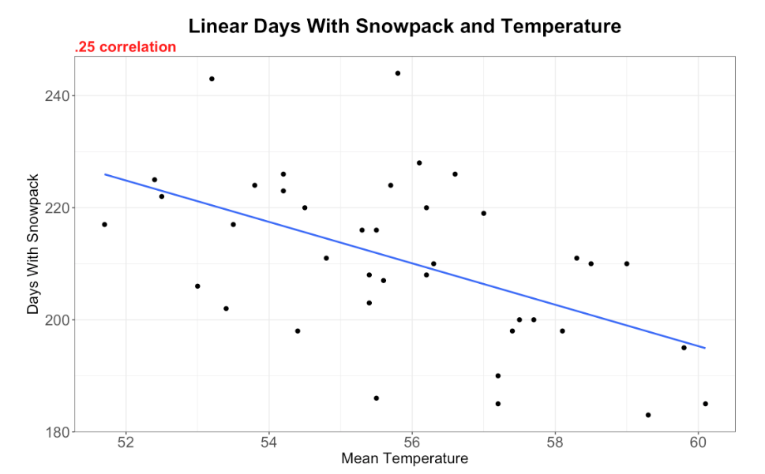

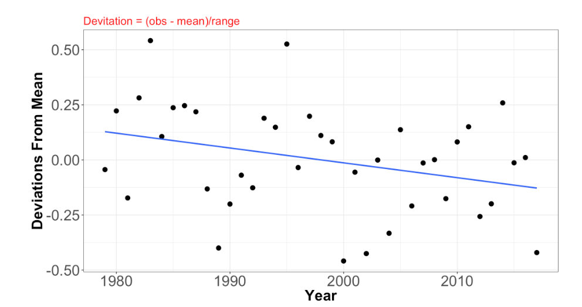

How does **warming climate affect snow pack at different elevations at different months**? The answer to this question helps us understand how snow pack would be affected in each month, which would help us know how certain ski-resorts might have to close sooner than others, due to elevations being affected differently.

The following graphic offers many insights, including that **lower elevations in the spring might be affected more**, shown by the steeper slope. A multiple regression with a triple interaction could be created to confirm this. I’m guessing this is the case because snow pack probably decreases with temperature at a constant rate across all elevations, but the difference is that within a certain month, the higher elevations are experiencing lower temperatures, and therefore its snow pack decreases at a lower rate.

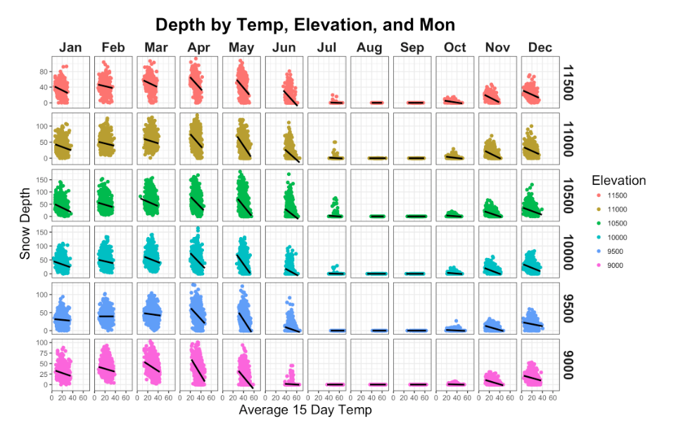

Finally, **what is the yearly snow pack trend at different elevations?**.

For this visualization, I chose to look at May because if temperature rose, May would be impacted more, temperature increase would increase the amount of time stations would stay above freezing. Here we can deduce that snow pack is gradually decreasing, and that elevations are affected uniformly.

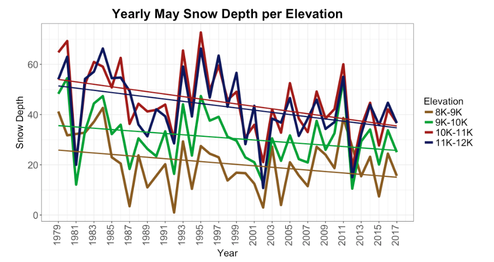

Conclusion

What did we learn about Colorado’s climate and warming temperatures? We learned that **daily low temperatures are rising over time**, that **snow pack is declining over time**, which also **decreases the snow season length**, and that **snow depth overall decreases uniformly with elevation**, but **lower elevations seem to be affected more in spring months**.

We also learned that weather data can be interpreted in many ways. Keep in mind I only imputed the **semi-monthly** aggregations, and that the same or another process would have to be done with other time period summaries. A much more in-depth analysis could be done for any step of the process, and I only used one of several ways to impute problematic values.

That being said, throughout the process I acquired new programming skills *(for example using Purrr)*, became faster in creating graphics with **ggplot2**, and strengthened my understanding of **linear regression**. Through the many reports I had to create, I also gained more experience in **data journalism**, or telling the story.

I thank all of the teachers with whom I’ve had the privilege to be in their class, the students that aided in those classes, whom have helped me to learn the tools needed to be able to analyze data best.

Please visit my [LinkedIn](https://www.linkedin.com/in/akwolfe/) and my [data science profile](https://roctober92.github.io/portfolio/) for more information about my experiences and work.

Thanks for reading!